# Becas

Lluís Revilla Sancho

4/27/2019

# Exploring the I+D+i in Spain

Recently my group got awarded with a grant. [Here](https://twitter.com/AgEInves/status/1121693189897723909) is an announcement to the social media:

> 1.855 proyectos han sido seleccionados de un total de 4.308 presentados.

> La inversión asciende a 252,2 millones de euros.

There is lot of discussion about the amount and percentage Spain should invest in research and development. Here I will analyze the document of this grant:

From the document the more important thing are the tables at the annex, from the document linked at the tweet above:

> Anexo I: Relación de proyectos de investigación con propuesta de financiación Anexo II: Propuesta de financiación de cada proyecto Anexo III: …condiciones de la ayuda… Anexo IV: Relación de proyectos a los que no se propone financiación Anexo V: ITI CÁDIZ

Really we are interested on annex 1, 2, and 4. (I won’t analyse the specific ITI for Cádiz)

## Original data

The raw data is a pdf, so we need to extract the tables to be able to analyze the content.

## Obtaining the data

First we need to convert from pdf to text. A quick search pointed me to an [entry](https://medium.com/@CharlesBordet/how-to-extract-and-clean-data-from-pdf-files-in-r-da11964e252e) which recommends [`pdftools`](https://cran.r-project.org/package=pdftools)

```r
library("pdftools")
pdf <- "http://www.ciencia.gob.es/stfls/eSede/Ficheros/2019/PRP_Retos_Investigacion_2018.pdf"
text <- pdf_text(pdf)
document <- sapply(text, function(page) {
  lines <- strsplit(page, "\\n")
  lapply(lines, trimws)
}, USE.NAMES = FALSE)
```

By manually inspecting the file we find that the relevant annexes are in these pages:

```r
annex1 <- 4:118
annex2 <- 119:182
annex4 <- 190:309
annex5 <- 310:312
interesting <- list(annex1, annex2, annex4, annex5)
names(interesting) <- c("annex1", "annex2", "annex4", "annex5")
```

Next step is to clean the data to convert them to tables. We start by first removing the header and the notes at the end of the tables (They include the signature and the name of the file/grant):

```r
annexes <- lapply(interesting, function(x, document) {
  document[x]
}, document = document)
```

Now we want to split by field (that is if there is more than two spaces we consider it a field). We first needed to analyze those that didn’t split in the expected number of fields:

```r
clean_entry <- function(x) {
  y <- gsub("(UNIVERSITAT POLITECNICA DE CATALUNYA)",
            " \\1 ", x)
  y <- gsub("(INVESTIGACIONES CIENTIFICAS \\(CSIC\\) )",
            " CONSEJO SUPERIOR DE \\1  ", y)
  y <- gsub("ENERGIGUNE ENERGIGUNE",
            "ENERGIGUNE  ENERGIGUNE", y)
  y <- gsub("(CIEMAT - MONCLOA)", " \\1", y)
  y <- gsub("(CIEMAT\\))", "\\1 ", y)
  y <- gsub("( DE VIC )", "\\1 ", y)
  y <- gsub("( DE COMPOSTELA )", "\\1 ", y)
  y <- gsub("( PABLO CEU )", "\\1 ", y)
  y <- gsub("( UNIVERSITAT POMPEU FABRA )", "\\1 ", y)
  y <- gsub("(CCT\\s+)", "CCT ", y)
  y <- gsub("(APLICACIONES FORESTALES CCT)", "\\1 ", y)
  y <- gsub("( \\(INTA\\))", "\\1 ", y)
  y <- gsub("( \\(INIA\\))", "\\1 ", y)
  y <- gsub("(JOSE MARIA ARIZMENDIARRIETA S. COOP.)", "\\1 ", y)
  y <- gsub("(UNIVERSIDAD AUTONOMA DE BARCELONA)", "\\1 ", y)
  y <- gsub("(UNIVERSIDAD DE MADRID)", "\\1 ", y)
  y <- gsub("(UNIVERSIDAD CARLOS III DE MADRID)", "\\1 ", y)
  y <- gsub("(UNIVERSIDAD COMPLUTENSE DE MADRID)", "\\1 ", y)
  y <- gsub("(UNIVERSIDAD POLITECNICA DE MADRID)", "\\1 ", y)
  y <- gsub("( DE VALÈNCIA )", "\\1 ", y)
  y <- gsub("(UNIVERSIDAD DE CASTILLA-LA MANCHA)", "\\1 ", y)
  y <- gsub("(DE LA IGLESIA DE DEUSTO)", "\\1 ", y)
  y <- gsub("(ISLAS BALEARES )", "\\1 ", y)
  y <- gsub("(POLITÉCNICA DE CARTAGENA )", "\\1 ", y)
  y <- gsub("\\s([A-Z][0-9]+[A-Z]?)\\s", "  \\1  ",  y, perl = TRUE)

  #  Numbers
  y <- gsub("1.246.300,00 1.030.000,00\\s", "1.246.300,00  1.030.000,00",  y)
  y <- gsub("2.178.000,00 1.800.000,00\\s", "2.178.000,00  1.800.000,00",  y)
  y <- gsub("1.573.000,00 1.300.000,00\\s", "1.573.000,00  1.300.000,00",  y)
  y <- gsub("2.372.205,00 1.960.500,00\\s", "2.372.205,00  1.960.500,00",  y)

  #
  y <- gsub("(TARRASENSE - LEITAT )", "\\1 ",  y)
  y <- gsub("CENTRO DE INVESTIGACIONES CIENTÍFICAS CENTRO DE INVESTIGACIONES CIENTÍFICAS",
            "CENTRO DE INVESTIGACIONES CIENTÍFICAS  CENTRO DE INVESTIGACIONES CIENTÍFICAS",  y)
  y <- gsub("(CENTRO INVESTIGACION BIOMEDICA EN RED )", "\\1 ",  y)
  y <- gsub("(FUNDACION CENTRO DE CIRUGIA DE MINIMA )", "\\1 ",  y)
  y <- gsub("(INSTITUTO NACIONAL DE INVESTIGACIÓN Y )", "\\1 ",  y)

  #
  y <- gsub("( AGENCIA ESTATAL CONSEJO)", " \\1",  y)
  y <- gsub("(FUNDACION PARA LA GESTION DE HOSPITAL PUERTA DEL)", "\\1  \\1",  y)
  y <- gsub("(METODOS AVANZADOS DE)", "\\1 ",  y)
  y <- gsub("( UNIVERSIDAD DE CADIZ)", " \\1 ",  y)

  # split
  y <- strsplit(y, "\\s{2, }")
  y <- unlist(y)
  y
}

annexes_field <- sapply(annexes, function(x) {
  sapply(x, function(pages) {
    # keep those lines that start with the name of an application
    entries <- grepl("^RTI", pages)
    if (any(entries)) {
      lapply(pages[entries], clean_entry)
    }
  })
})
```

We write some function to help us tidy the data, the first one to convert it into a data.frame The second one to convert a factor which is really a number into a number:

```r
doc2df <- function(documents, colnames) {
  anext <- sapply(documents, function(page, ncol) {
     # Filter by the number of
    y <- page[lengths(page) == ncol]

    if (length(y) > 1) {
      t(simplify2array(y))
    }}, ncol = length(colnames))
  # Convert to a data.frame
  anext <- as.data.frame(do.call(rbind, anext))
  # Set the colnames
  colnames(anext) <- colnames
  anext
}

fact2number <- function(f){
   as.numeric(levels(f))[f]
}
```

# Annex 1 : Succesful applications:

We can use this functions on the first annex:

```r
library("forcats")
annex1 <- doc2df(annexes_field[[1]],
                 c("reference", "area", "subarea", "entity", "center", "NIF",
                   "CA", "years", "predoc"))

annex1$predoc <- fact2number(annex1$predoc)
annex1$years <- fact2number(annex1$years)
annex1$CA <- fct_relabel(annex1$CA,  ~ gsub("^A$", "EXTREMADURA", .))
annex1$CA <- fct_relabel(annex1$CA,  ~ gsub("^S$", "PDO.ASTURIAS", .))
annex1$CA <- fct_relabel(annex1$CA,  ~ gsub("^MANCHA$", "CASTILLA-LA MANCHA", .))
annex1$CA <- fct_relabel(annex1$CA,  ~ gsub("^LEON$", "CASTILLA Y LEON", .))
annex1$CA <- fct_relevel(annex1$CA, sort)
```

We can see some interesting summary here:

```r
# Is there a relationship between duration of the project and possibility to employ someone?
table(annex1$years, annex1$predoc)
```

```
##
##        0    1
##   2   25    0
##   3 1108  505
##   4  143   74
```

```r
# Which NIF recieves more grants?
tail(sort(table(annex1$NIF)))
```

```
##
## Q4618001D Q4118001I Q4618002B Q0818001J Q2818014I Q2818002D
##        50        53        59        63        79       300
```

```r
# Which CA recieves more grants?
sort(table(annex1$CA), decreasing = TRUE)
```

```
##
##             MADRID           CATALUÑA          ANDALUCIA
##                438                409                259
##       C.VALENCIANA         PAIS VASCO            GALICIA
##                232                 96                 92
##    CASTILLA Y LEON             ARAGON             MURCIA
##                 61                 52                 42
##       PDO.ASTURIAS            NAVARRA CASTILLA-LA MANCHA
##                 35                 30                 28
##           BALEARES          CANTABRIA           CANARIAS
##                 20                 20                 19
##        EXTREMADURA           LA RIOJA
##                 14                  8
```

With the clean data and in a data.frame we can plot it to gain more insight:

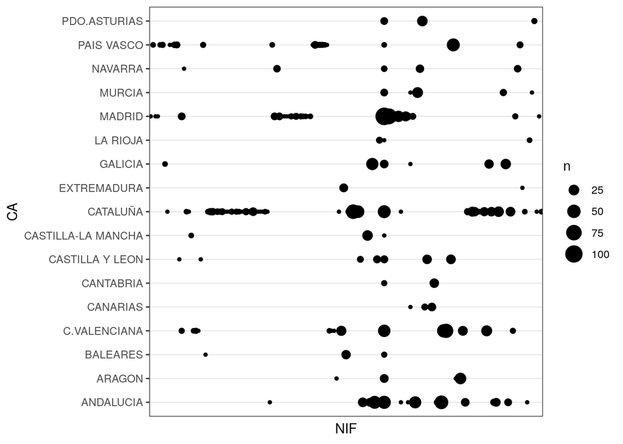

```r
library("ggplot2")
theme_set(theme_bw())
remove_x_text <- theme(axis.text.x = element_blank(),
        axis.ticks.x = element_blank(),
        panel.grid.major.x = element_blank())
remove_y_text <- theme(axis.text.y = element_blank(),
        axis.ticks.y = element_blank(),
        panel.grid.major.y = element_blank())
ggplot(annex1) +
  geom_count(aes(NIF, CA)) +
  remove_x_text
```

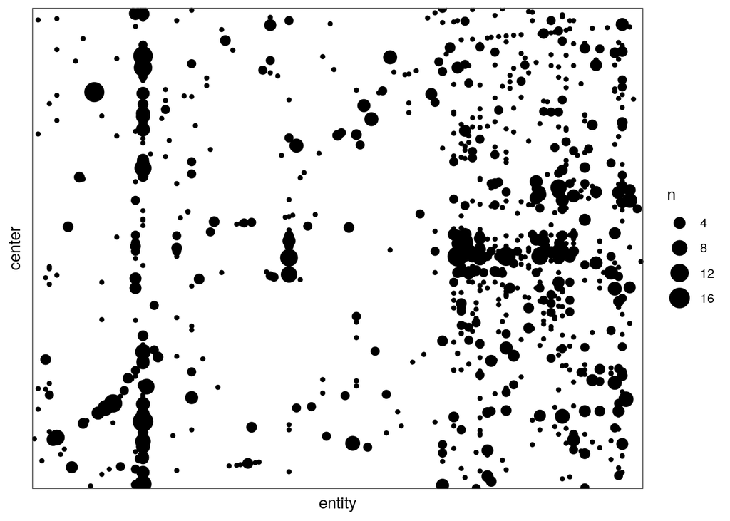

```r
ggplot(annex1) +
  geom_count(aes(entity, center)) +
  remove_x_text +
  remove_y_text
```

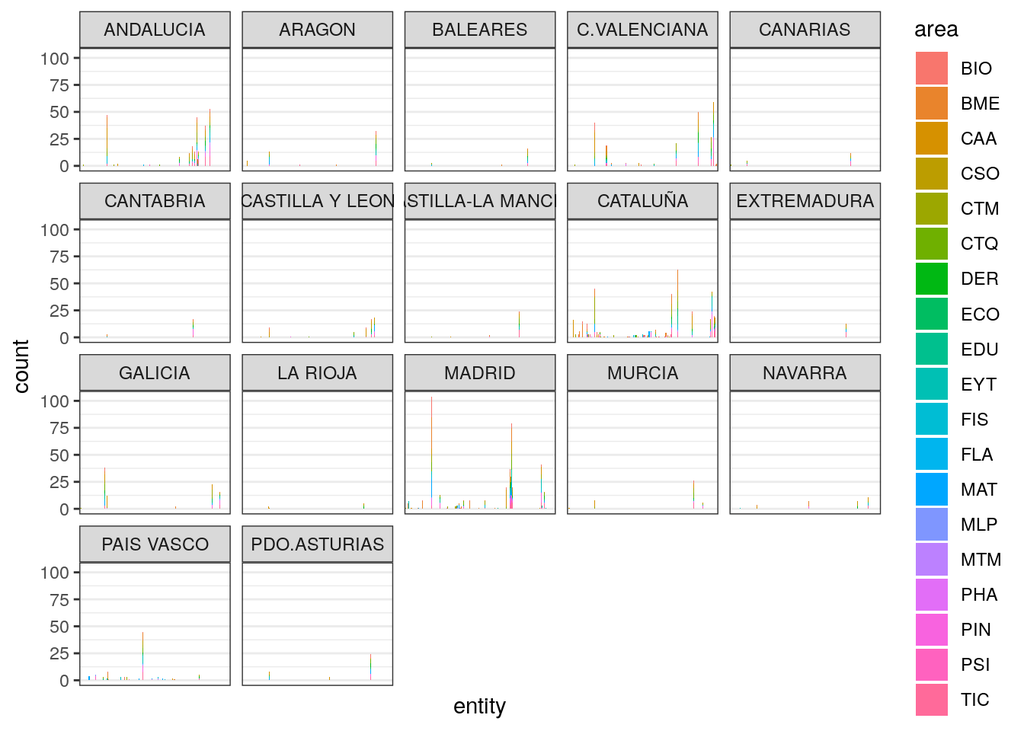

```r
ggplot(annex1) +
  geom_bar(aes(entity, fill = area)) +
  facet_wrap(~CA) +
  remove_x_text
```

```r
library("dplyr")
annex1 %>%
  group_by(NIF, center) %>%
  summarise(people = sum(predoc)) %>%
  filter(people != 0) %>%
  arrange(desc(people))
```

```
## # A tibble: 400 x 3
## # Groups:   NIF [108]
##    NIF       center                      people
##    <fct>     <fct>                        <dbl>
##  1 G82316753 CARLOS III                       6
##  2 Q5856414G PI I SUNYER                      6
##  3 G64045719 CATALUNYA                        5
##  4 G81972242 INVESTIGACIONES ONCOLOGICAS      5
##  5 G95229142 CIC BIOGUNE                      5
##  6 Q1818002F FACULTAD DE CIENCIAS             5
##  7 Q2818002D (ITQ)                            5
##  8 Q2818002D BIOLOGICAS (CIB)                 5
##  9 Q2818002D SEVERO OCHOA (CBM)               5
## 10 Q2818013A FACULTAD DE CIENCIAS             5
## # … with 390 more rows
```

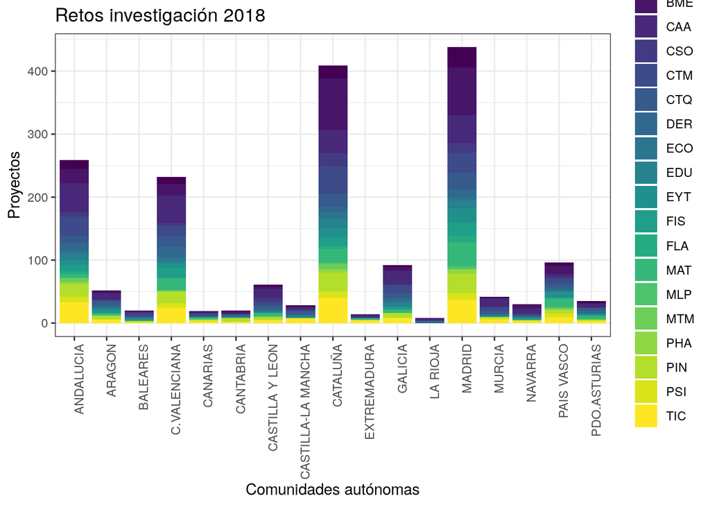

```r
annex1 %>% ggplot()+
  geom_bar(aes(CA, fill = area)) +
  scale_fill_viridis_d() +
  theme(axis.text.x = element_text(angle = 90, hjust = 1)) +
  labs(title = "Retos investigación 2018", x = "Comunidades autónomas",
       y = "Proyectos")
```

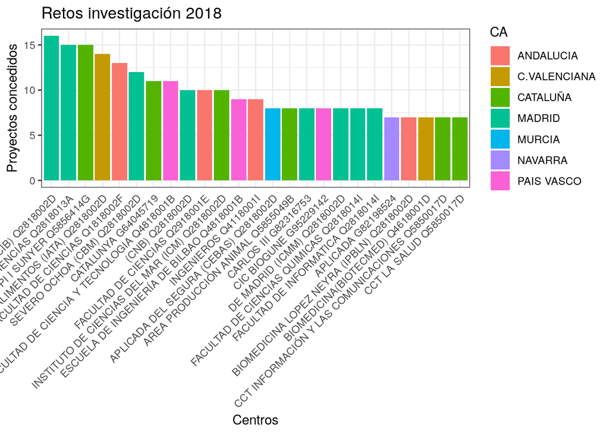

```r
annex1 %>%
  group_by(center, NIF) %>%
  summarise(n = n(), Site = unique(paste(center, NIF)), CA = unique(CA)) %>%
  arrange(desc(n)) %>%
  head(n = 25) %>%
  ggplot() +
  geom_col(aes(fct_reorder(Site, order(n, decreasing = TRUE)), n, fill = CA))  +
  theme(axis.text.x = element_text(angle = 45, hjust = 1),
        axis.ticks.x = element_blank(),
        axis.line.x = element_blank()) +
  labs(title = "Retos investigación 2018", x = "Centros",
       y = "Proyectos concedidos")
```

# Annex2: Economic data

The money assigned to the approved projects is in the annex 2. We prepare the data:

```r
annex2 <- doc2df(annexes_field[[2]], c("reference", "total", "direct", "indirect", "reimbursable", "grant",
                  "grant_2019", "reimbursable_2019", "total_2019",
                  "grant_2020", "grant_2021", "grant_2022"))
# Convert text to numbers for R
annex2 <- sapply(annex2, function(x) {
  y <- gsub("\\.", "", x)
  gsub(",", ".", y)
})
annex2 <- as.data.frame(annex2)
annex2[, 2:12] <- sapply(annex2[, 2:12], fact2number)
```

Then we can explore the projects:

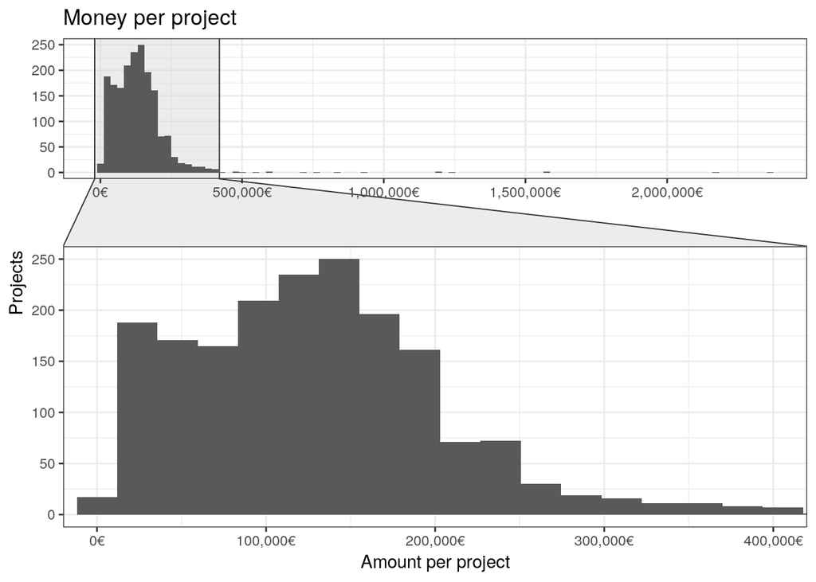

```r
library("ggforce")
library("scales")
# With help from: https://stackoverflow.com/a/32265122/2886003
euro_format <- dollar_format(suffix = "€", prefix = "")
ggplot(annex2) +
  geom_histogram(aes(total), bins = 100) +
  scale_x_continuous(labels = euro_format) +
  facet_zoom(xlim = c(0, 400000)) +
  labs(y = "Projects", x = "Amount per project", title = "Money per project")
```

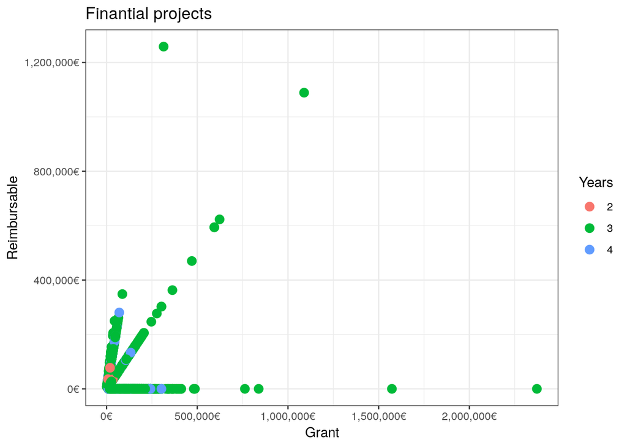

```r
df <- merge(annex1, annex2)

ggplot(df) +
  geom_point(aes(grant, reimbursable, col = as.factor(years)), size = 3) +
  scale_x_continuous(labels = euro_format) +
  scale_y_continuous(labels = euro_format) +
  labs(x = "Grant", y = "Reimbursable",
       title = "Finantial projects",
       col = "Years")
```

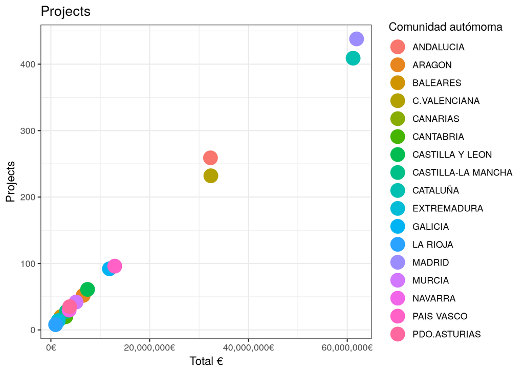

```r
df %>%
  group_by(CA) %>%
  summarise(total_CA =  sum(total), n = n(), mean = total_CA/n, sd = sd(total)) %>%
  ggplot() +
  scale_x_continuous(labels = euro_format) +
  geom_point(aes(total_CA, n, col = CA), size = 6) +
  labs(x = "Total €", y = "Projects", title = "Projects", col = "Comunidad autómoma")
```

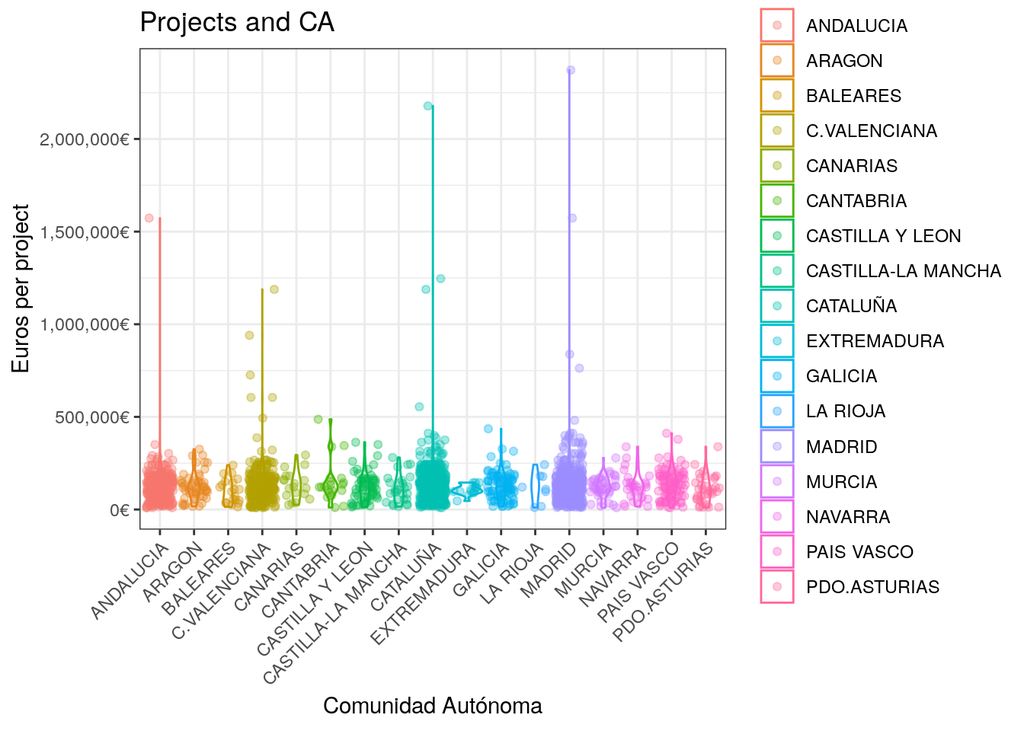

```r
df %>%
  ggplot() +
  geom_violin(aes(CA, total, col = CA)) +
  geom_jitter(aes(CA, total, col = CA), alpha = 0.35) +
  scale_y_continuous(labels = euro_format) +
  theme(axis.text.x = element_text(angle = 45, hjust = 1)) +
  labs(y = "Euros per project", title = "Projects and CA",
       x = "Comunidad Autónoma")
```

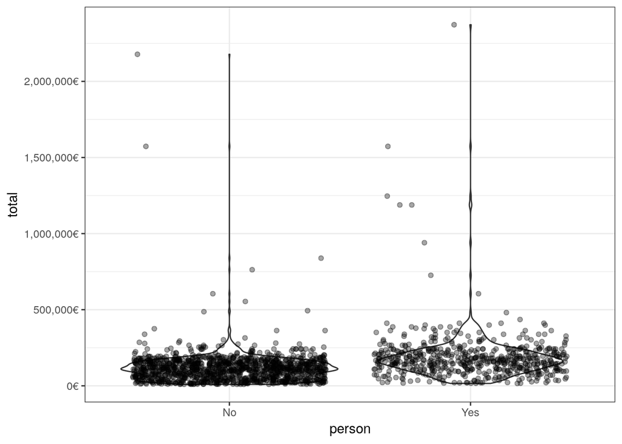

```r
df %>%
  mutate(person = if_else(predoc == 1, "Yes", "No")) %>%
  filter(total != 0) %>%
  ggplot() +
  geom_violin(aes(person, total)) +
  geom_jitter(aes(person, total), alpha = 0.35) +
  scale_y_continuous(labels = euro_format)
```

We can see that projets that employ someone are provided with more money.

## Annex IV Unsuccesful applications

So far we looked at the succesful grants, we also have information about the ones that are not succesful.

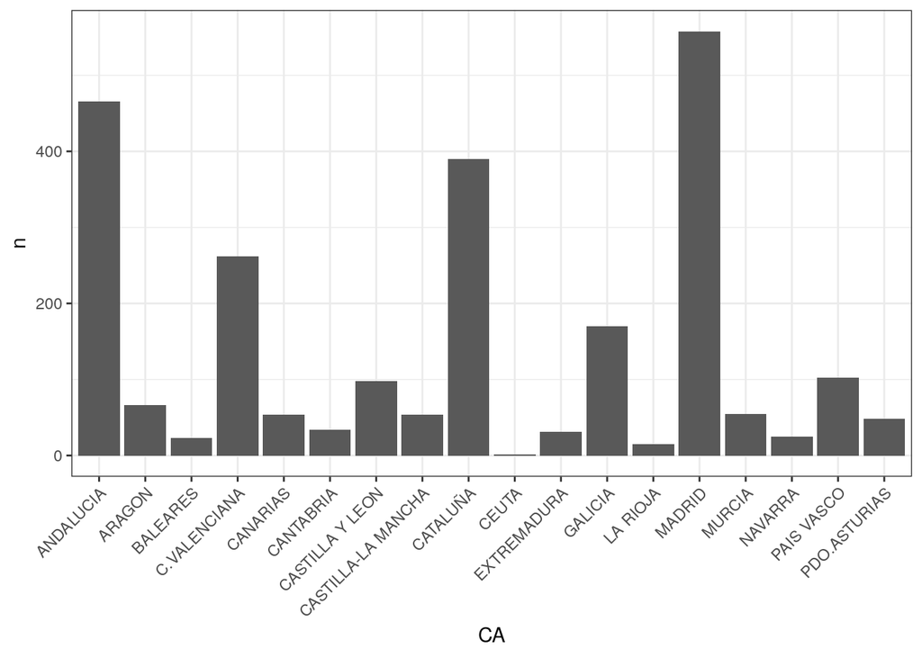

```r
annex4 <- doc2df(annexes_field[[3]],
                 c("reference", "area", "subarea", "entity", "center", "NIF", "CA"))

annex4$CA <- fct_relevel(annex4$CA, sort)
annex4 %>%
  group_by(CA) %>%
  count() %>%
  ggplot() +
  geom_col(aes(CA, n)) +
  theme(axis.text.x = element_text(angle = 45, hjust = 1))
```

## All

Merging both data.frames we can explore the success rates, but first we need to clean them a bit:

```r
df <- merge(df, annex4, all = TRUE)

levels(df$CA) <- gsub("^MANCHA$", "CASTILLA-LA MANCHA", levels(df$CA))
df$CA <- fct_relevel(df$CA, sort)
df$NIF <- fct_relevel(df$NIF, sort)
numeric_colnames <- colnames(df)
numeric_colnames <- numeric_colnames[-c(1, 13:18)]
df[, numeric_colnames][is.na(df[, numeric_colnames])] <- 0
```

Now we can explore the success application rate. The global success rate is 0.4306942

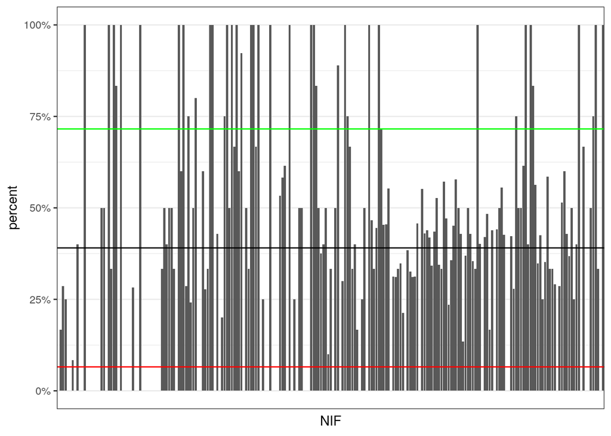

```r
# By Nif
global <- df %>%
  group_by(NIF) %>%
  summarise(rate = sum(total != 0)/n()) %>%
  ungroup() %>%
  summarise(mean = mean(rate), sd = sd(rate))
df %>%
  group_by(NIF) %>%
  summarise(n = n(), granted = sum(total != 0), percent = granted/n) %>%
  arrange(desc(percent), desc(n)) %>%
  ggplot() +
  geom_col(aes(NIF, percent)) +
  geom_hline(yintercept = c(global$mean,
                            global$mean - global$sd,
                            global$mean + global$sd),
             col = c("black", "red", "green")) +
  scale_y_continuous(labels = scales::percent) +
  remove_x_text
```

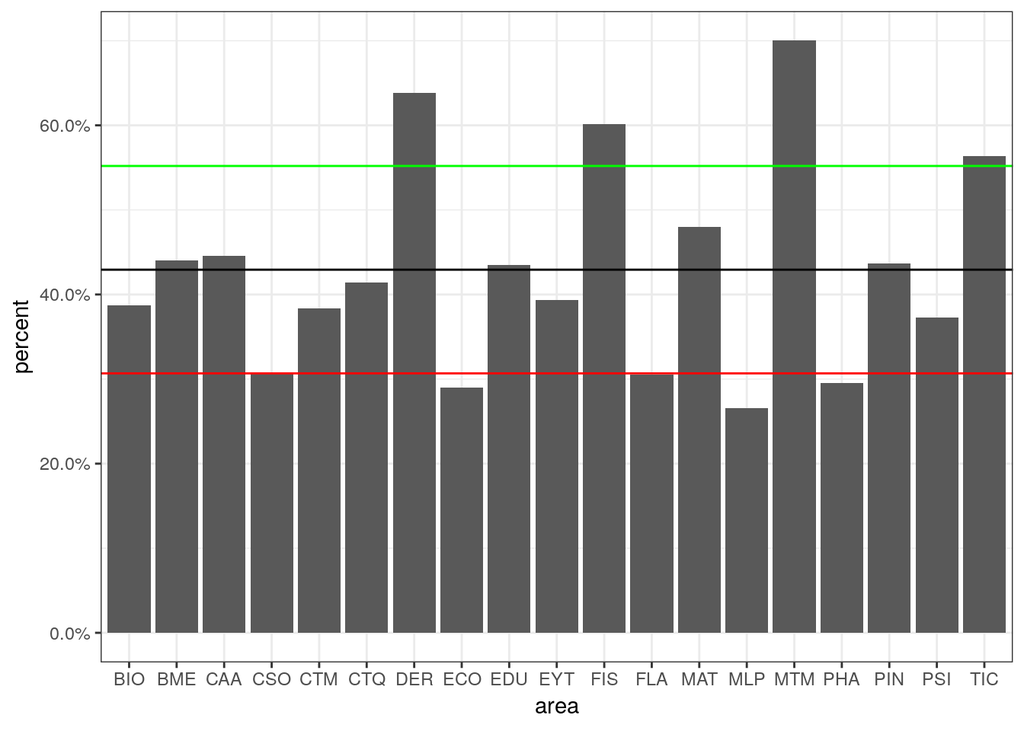

```r
global <- df %>%
  group_by(area) %>%
  summarise(rate = sum(total != 0)/n()) %>%
  ungroup() %>%
  summarise(mean = mean(rate), sd = sd(rate))
df %>%
  group_by(area) %>%
  summarise(n = n(), granted = sum(total != 0), percent = granted/n) %>%
  arrange(desc(percent), desc(n)) %>%
  ggplot() +
  geom_col(aes(area, percent)) +
  geom_hline(yintercept = c(global$mean,
                            global$mean - global$sd,
                            global$mean + global$sd),
             col = c("black", "red", "green")) +
  scale_y_continuous(labels = scales::percent)
```

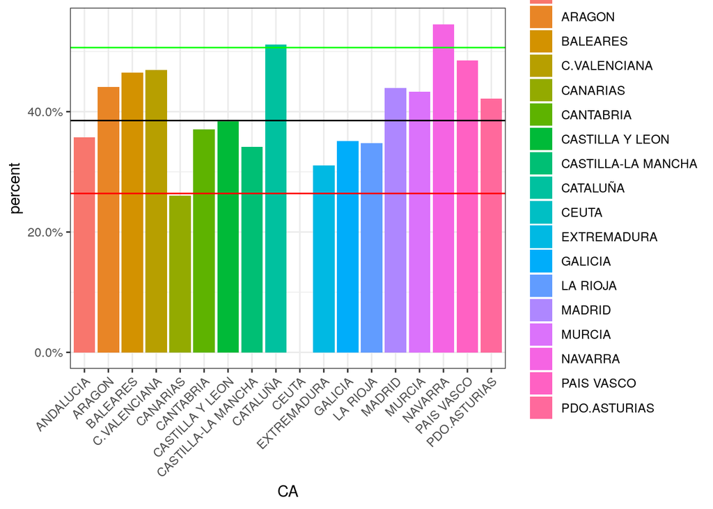

```r
global <- df %>%
  group_by(CA) %>%
  summarise(rate = sum(total != 0)/n()) %>%
  ungroup() %>%
  summarise(mean = mean(rate), sd = sd(rate))
df %>%
  group_by(CA) %>%
  summarise(n = n(), granted = sum(total != 0), percent = granted/n) %>%
  arrange(desc(percent), desc(n)) %>%
  ggplot() +
  geom_col(aes(CA, percent, fill = CA)) +
  geom_hline(yintercept = c(global$mean,
                            global$mean - global$sd,
                            global$mean + global$sd),
             col = c("black", "red", "green")) +
  scale_y_continuous(labels = scales::percent) +
  theme(axis.text.x = element_text(angle = 45, hjust = 1))
```

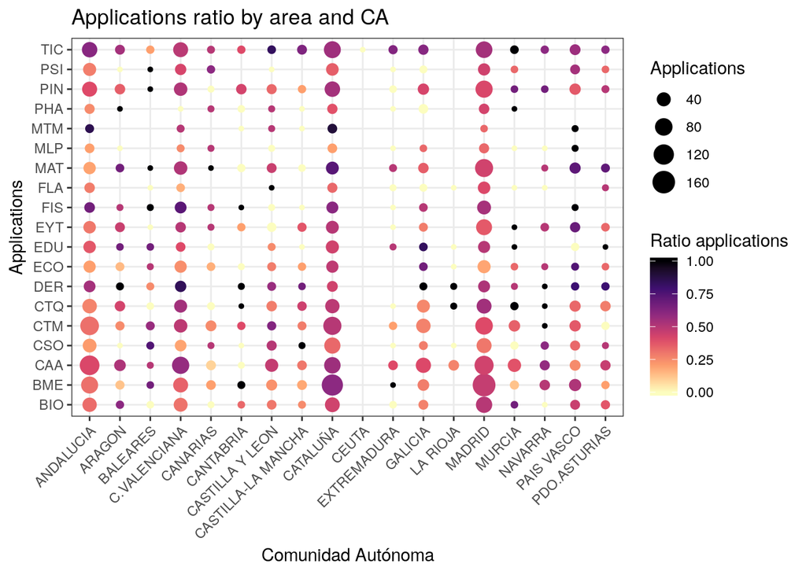

```r
df %>%
  group_by(CA, area) %>%
  summarise(n = n(), ratio = sum(total != 0)/n) %>%
  ggplot() +
  geom_point(aes(CA, area, size = n, col = ratio)) +
  theme(axis.text.x = element_text(angle = 45, hjust = 1),
        panel.ontop = element_blank()) +
  labs(y = "Applications", title = "Applications ratio by area and CA",
       x = "Comunidad Autónoma", col = "Ratio applications",
       size = "Applications") +
  scale_color_viridis_c(option = "A", direction = -1)
```

We can see that some few caomunidades autonomas have grants from all areas.

# Bonus

For completeness we look at the last annex.

```r
annex5 <- doc2df(annexes_field[[4]], c("reference", "area", "subarea", "title", "entity", "center", "NIF", "CA"))
```